# STAT140B Project 1

Van Nguyen

2025-02-28

# Project 1

## 1: Describe the dataset

```r
# Dataset: https://archive.ics.uci.edu/dataset/165/concrete+compressive+strength
constr <- read_excel("C:\\Users\\LapWork\\Downloads\\concrete+compressive+strength\\Concrete_Data.xls")
# Renaming for convenience. Beside Age (Days), and Concrete Compressive strength (megapascals) everything else is in kg in a m^3 mixture.
colnames(constr) <- c("Cement","Blast Furnace Slag","Fly Ash","Water","Superplasticizer","Coarse Aggregate","Fine Aggregate","Age","Concrete compressive strength")
attach(constr)
```

Concrete is one of the most commonly used building material, whether they are used as walls, floors or as the foundation to a building. This dataset aims to measure the compressive strength of concrete and see what factor affects it.

## 2: Examine the data

```r
summary(constr)
```

```
##      Cement      Blast Furnace Slag    Fly Ash           Water
##  Min.   :102.0   Min.   :  0.0      Min.   :  0.00   Min.   :121.8
##  1st Qu.:192.4   1st Qu.:  0.0      1st Qu.:  0.00   1st Qu.:164.9
##  Median :272.9   Median : 22.0      Median :  0.00   Median :185.0
##  Mean   :281.2   Mean   : 73.9      Mean   : 54.19   Mean   :181.6
##  3rd Qu.:350.0   3rd Qu.:142.9      3rd Qu.:118.27   3rd Qu.:192.0
##  Max.   :540.0   Max.   :359.4      Max.   :200.10   Max.   :247.0
##  Superplasticizer Coarse Aggregate Fine Aggregate       Age
##  Min.   : 0.000   Min.   : 801.0   Min.   :594.0   Min.   :  1.00
##  1st Qu.: 0.000   1st Qu.: 932.0   1st Qu.:731.0   1st Qu.:  7.00
##  Median : 6.350   Median : 968.0   Median :779.5   Median : 28.00
##  Mean   : 6.203   Mean   : 972.9   Mean   :773.6   Mean   : 45.66
##  3rd Qu.:10.160   3rd Qu.:1029.4   3rd Qu.:824.0   3rd Qu.: 56.00
##  Max.   :32.200   Max.   :1145.0   Max.   :992.6   Max.   :365.00
##  Concrete compressive strength
##  Min.   : 2.332
##  1st Qu.:23.707
##  Median :34.443
##  Mean   :35.818
##  3rd Qu.:46.136
##  Max.   :82.599
```

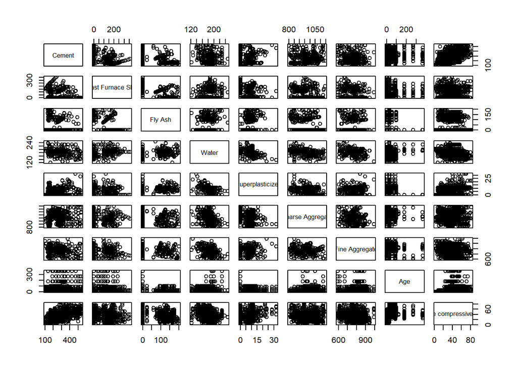

```r
# There is no missing data
plot(constr)
```

```r
# Fly Ash may look weird with a black bar on the left, but its probaly the result of the many entries being 0. There looks to be a linear relationship between cement and concrete compressive strength.Its hard to conclusively tell but there may be negative linear relationship between Cement and Fly Ash.
cor(constr)
```

```
##                                    Cement Blast Furnace Slag      Fly Ash
## Cement                         1.00000000        -0.27519344 -0.397475440
## Blast Furnace Slag            -0.27519344         1.00000000 -0.323569468
## Fly Ash                       -0.39747544        -0.32356947  1.000000000
## Water                         -0.08154361         0.10728594 -0.257043997
## Superplasticizer               0.09277137         0.04337574  0.377339559
## Coarse Aggregate              -0.10935604        -0.28399823 -0.009976788
## Fine Aggregate                -0.22272017        -0.28159326  0.079076351
## Age                            0.08194726        -0.04424580 -0.154370165
## Concrete compressive strength  0.49783272         0.13482445 -0.105753348
##                                     Water Superplasticizer Coarse Aggregate
## Cement                        -0.08154361       0.09277137     -0.109356039
## Blast Furnace Slag             0.10728594       0.04337574     -0.283998230
## Fly Ash                       -0.25704400       0.37733956     -0.009976788
## Water                          1.00000000      -0.65746444     -0.182311668
## Superplasticizer              -0.65746444       1.00000000     -0.266302755
## Coarse Aggregate              -0.18231167      -0.26630276      1.000000000
## Fine Aggregate                -0.45063498       0.22250149     -0.178505755
## Age                            0.27760443      -0.19271652     -0.003015507
## Concrete compressive strength -0.28961348       0.36610230     -0.164927821
##                               Fine Aggregate          Age
## Cement                           -0.22272017  0.081947264
## Blast Furnace Slag               -0.28159326 -0.044245801
## Fly Ash                           0.07907635 -0.154370165
## Water                            -0.45063498  0.277604429
## Superplasticizer                  0.22250149 -0.192716518
## Coarse Aggregate                 -0.17850575 -0.003015507
## Fine Aggregate                    1.00000000 -0.156094049
## Age                              -0.15609405  1.000000000
## Concrete compressive strength    -0.16724896  0.328876976
##                               Concrete compressive strength
## Cement                                            0.4978327
## Blast Furnace Slag                                0.1348244
## Fly Ash                                          -0.1057533
## Water                                            -0.2896135
## Superplasticizer                                  0.3661023
## Coarse Aggregate                                 -0.1649278
## Fine Aggregate                                   -0.1672490
## Age                                               0.3288770
## Concrete compressive strength                     1.0000000
```

```r
# some correlation between Cement and Concrete compressive strength, water and Fine Aggregate with correlation about 0.5, positive and negative respectively. Water and Superplasticizer has more correlation with value of -0.65746444.
```

## 3: Describe what you want to model

The goal is to see what factors affect Concrete compressive strength so that will be the output variable. For initial predictors, I’ll choose to use all the other remaining variable since all of them at a glance look important. I’ll will additionally use an interaction term between water and Superplasticizer since both are highly correlated with each other. If some are found not useful, I can remove them in future version of the model.

## 4: Develop a linear regression model for your data

```r
attach(constr)
mod1 <- lm(`Concrete compressive strength` ~ . + Water * Superplasticizer, data = constr)
summary(mod1)
```

```
##
## Call:
## lm(formula = `Concrete compressive strength` ~ . + Water * Superplasticizer,
##     data = constr)
##
## Residuals:
##     Min      1Q  Median      3Q     Max
## -30.276  -6.106   0.275   6.970  32.859
##
## Coefficients:
##                         Estimate Std. Error t value Pr(>|t|)
## (Intercept)             1.031270  26.607219   0.039   0.9691
## Cement                  0.116854   0.008392  13.925  < 2e-16 ***
## `Blast Furnace Slag`    0.096869   0.010082   9.608  < 2e-16 ***
## `Fly Ash`               0.065254   0.013105   4.979 7.49e-07 ***
## Water                  -0.246029   0.043410  -5.668 1.88e-08 ***
## Superplasticizer       -2.263098   0.481230  -4.703 2.92e-06 ***
## `Coarse Aggregate`      0.015388   0.009280   1.658   0.0976 .
## `Fine Aggregate`        0.016951   0.010574   1.603   0.1092
## Age                     0.121470   0.005519  22.009  < 2e-16 ***
## Water:Superplasticizer  0.015650   0.002894   5.407 7.98e-08 ***
## ---
## Signif. codes:  0 '***' 0.001 '**' 0.01 '*' 0.05 '.' 0.1 ' ' 1
##
## Residual standard error: 10.26 on 1020 degrees of freedom
## Multiple R-squared:  0.6262, Adjusted R-squared:  0.6229
## F-statistic: 189.8 on 9 and 1020 DF,  p-value: < 2.2e-16
```

```r
# Adjusted R-squared: 0.6229 Coarse Aggregate and Fine Aggregate's p-vaule > 0.05. Next model remove Fine Aggregate

mod2 <- lm(`Concrete compressive strength` ~ . + Water * Superplasticizer - `Fine Aggregate`, data = constr)
summary(mod2)
```

```
##
## Call:
## lm(formula = `Concrete compressive strength` ~ . + Water * Superplasticizer -
##     `Fine Aggregate`, data = constr)
##
## Residuals:
##     Min      1Q  Median      3Q     Max
## -30.198  -6.467   0.180   6.996  32.804
##
## Coefficients:
##                         Estimate Std. Error t value Pr(>|t|)
## (Intercept)            41.028246   9.247986   4.436 1.01e-05 ***
## Cement                  0.105304   0.004307  24.452  < 2e-16 ***
## `Blast Furnace Slag`    0.083008   0.005188  15.999  < 2e-16 ***
## `Fly Ash`               0.049270   0.008511   5.789 9.40e-09 ***
## Water                  -0.298735   0.028365 -10.532  < 2e-16 ***
## Superplasticizer       -2.328979   0.479840  -4.854 1.40e-06 ***
## `Coarse Aggregate`      0.003043   0.005181   0.587    0.557
## Age                     0.120854   0.005510  21.934  < 2e-16 ***
## Water:Superplasticizer  0.015910   0.002892   5.501 4.77e-08 ***
## ---
## Signif. codes:  0 '***' 0.001 '**' 0.01 '*' 0.05 '.' 0.1 ' ' 1
##
## Residual standard error: 10.27 on 1021 degrees of freedom
## Multiple R-squared:  0.6252, Adjusted R-squared:  0.6223
## F-statistic: 212.9 on 8 and 1021 DF,  p-value: < 2.2e-16
```

```r
# Adjusted R-squared: 0.6223. Adjusted R-squared decrease. Might be to to the minor correlation Fine Aggregate has with other predictors. Coarse Aggregate's p-value > p-vaule > 0.05. Next model remove Coarse Aggregate only instead.

mod3 <- lm(`Concrete compressive strength` ~ . + Water * Superplasticizer - `Coarse Aggregate`, data = constr)
summary(mod3)
```

```
##
## Call:
## lm(formula = `Concrete compressive strength` ~ . + Water * Superplasticizer -
##     `Coarse Aggregate`, data = constr)
##
## Residuals:
##     Min      1Q  Median      3Q     Max
## -30.590  -6.296   0.204   6.978  33.257
##
## Coefficients:
##                         Estimate Std. Error t value Pr(>|t|)
## (Intercept)            42.485109   9.118508   4.659 3.59e-06 ***
## Cement                  0.106023   0.005274  20.103  < 2e-16 ***
## `Blast Furnace Slag`    0.083593   0.006133  13.631  < 2e-16 ***
## `Fly Ash`               0.050610   0.009691   5.223 2.14e-07 ***
## Water                  -0.301461   0.027717 -10.876  < 2e-16 ***
## Superplasticizer       -2.358281   0.478204  -4.932 9.52e-07 ***
## `Fine Aggregate`        0.002399   0.005904   0.406    0.685
## Age                     0.121165   0.005521  21.947  < 2e-16 ***
## Water:Superplasticizer  0.015903   0.002893   5.497 4.87e-08 ***
## ---
## Signif. codes:  0 '***' 0.001 '**' 0.01 '*' 0.05 '.' 0.1 ' ' 1
##
## Residual standard error: 10.27 on 1021 degrees of freedom
## Multiple R-squared:  0.6252, Adjusted R-squared:  0.6222
## F-statistic: 212.9 on 8 and 1021 DF,  p-value: < 2.2e-16
```

```r
# Adjusted R-squared: 0.6222. Adjusted R-squared decrease. Might be same reason as previous model. Fine Aggregate's p-value > 0.05. Try removing both.

mod4  <- lm(`Concrete compressive strength` ~ . + Water * Superplasticizer - `Coarse Aggregate`- `Fine Aggregate`, data = constr)
summary(mod4)
```

```
##
## Call:
## lm(formula = `Concrete compressive strength` ~ . + Water * Superplasticizer -
##     `Coarse Aggregate` - `Fine Aggregate`, data = constr)
##
## Residuals:
##     Min      1Q  Median      3Q     Max
## -30.440  -6.396   0.212   6.939  33.087
##
## Coefficients:
##                         Estimate Std. Error t value Pr(>|t|)
## (Intercept)            45.549216   5.122370   8.892  < 2e-16 ***
## Cement                  0.104723   0.004190  24.995  < 2e-16 ***
## `Blast Furnace Slag`    0.082134   0.004968  16.531  < 2e-16 ***
## `Fly Ash`               0.048684   0.008449   5.762 1.10e-08 ***
## Water                  -0.305205   0.026130 -11.680  < 2e-16 ***
## Superplasticizer       -2.353516   0.477864  -4.925 9.83e-07 ***
## Age                     0.120996   0.005503  21.988  < 2e-16 ***
## Water:Superplasticizer  0.015929   0.002891   5.510 4.55e-08 ***
## ---
## Signif. codes:  0 '***' 0.001 '**' 0.01 '*' 0.05 '.' 0.1 ' ' 1
##
## Residual standard error: 10.26 on 1022 degrees of freedom
## Multiple R-squared:  0.6251, Adjusted R-squared:  0.6225
## F-statistic: 243.4 on 7 and 1022 DF,  p-value: < 2.2e-16
```

```r
# Adjusted R-squared: 0.6225. Slightly better than other two but does not compare to first model. Given the correlation reason from other two models, try incorporating interaction between correlated predictors water and Fine Aggregate

mod5 <- lm(`Concrete compressive strength` ~ . + Water * Superplasticizer + Water * `Fine Aggregate`, data = constr)
summary(mod5)
```

```
##
## Call:
## lm(formula = `Concrete compressive strength` ~ . + Water * Superplasticizer +
##     Water * `Fine Aggregate`, data = constr)
##
## Residuals:
##     Min      1Q  Median      3Q     Max
## -30.059  -6.149   0.221   6.958  32.779
##
## Coefficients:
##                          Estimate Std. Error t value Pr(>|t|)
## (Intercept)            -1.951e+01  3.581e+01  -0.545   0.5860
## Cement                  1.161e-01  8.438e-03  13.760  < 2e-16 ***
## `Blast Furnace Slag`    9.616e-02  1.012e-02   9.505  < 2e-16 ***
## `Fly Ash`               6.316e-02  1.333e-02   4.738 2.47e-06 ***
## Water                  -1.322e-01  1.397e-01  -0.946   0.3443
## Superplasticizer       -2.524e+00  5.694e-01  -4.433 1.03e-05 ***
## `Coarse Aggregate`      1.558e-02  9.284e-03   1.679   0.0935 .
## `Fine Aggregate`        4.687e-02  3.647e-02   1.285   0.1990
## Age                     1.209e-01  5.560e-03  21.746  < 2e-16 ***
## Water:Superplasticizer  1.715e-02  3.380e-03   5.072 4.67e-07 ***
## Water:`Fine Aggregate` -1.647e-04  1.921e-04  -0.857   0.3915
## ---
## Signif. codes:  0 '***' 0.001 '**' 0.01 '*' 0.05 '.' 0.1 ' ' 1
##
## Residual standard error: 10.26 on 1019 degrees of freedom
## Multiple R-squared:  0.6264, Adjusted R-squared:  0.6228
## F-statistic: 170.9 on 10 and 1019 DF,  p-value: < 2.2e-16
```

```r
# Adjusted R-squared: 0.6228. Second highest adjusted R-square value. Newly add interaction is not significant. both Aggregate still have high p-values. Since mod1 has the highest Adjusted R-squared, choose mod1 as final model
```

## 5: Examine and comment on model fit and assumptions

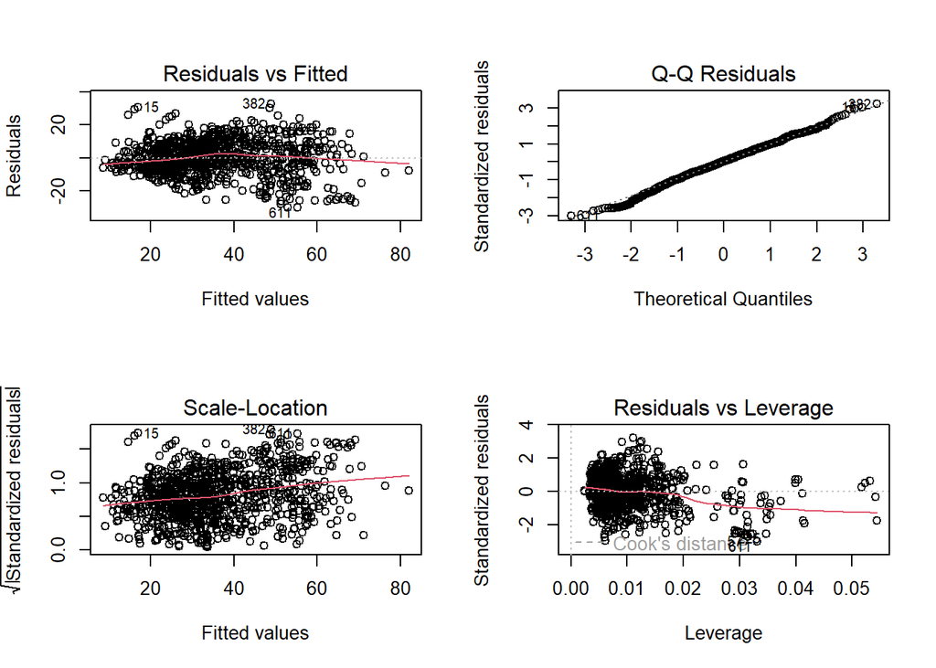

```r
par(mfrow = c(2, 2))
plot(mod1)
```

```r
vif(mod1)
```

```
## there are higher-order terms (interactions) in this model
## consider setting type = 'predictor'; see ?vif
```

```
##                 Cement   `Blast Furnace Slag`              `Fly Ash`
##               7.520051               7.397744               6.876585
##                  Water       Superplasticizer     `Coarse Aggregate`
##               8.402412              80.792337               5.090157
##       `Fine Aggregate`                    Age Water:Superplasticizer
##               7.027408               1.188391              73.389269
```

## 6: Concerns about model

The main concern about this model is the multicollinearity of the predictors. A mistake I made was passing off correlation values less than |0.4| as not significant and so I did not consider the interactions between predictors when initially creating the model. Future version of the model would look to incorporate more interactions between predictors into the model or do something else to account for or remove the multicollinearity.